# Assignmnet4_quant

Sage Grey

9/27/2020

## **Overview of Assignment**

The intention of Assignment 4 is to perform and analyze a linear regression from our DataSet. In this assignment I am continuing to use information about New Mexico from the 2018 American Community Survey. I am looking primarily at the following variables. There are 15,043 observations in this dataset.

#### **Variables**

**Continuous**  
1. Household Income (HINCP)  
2. Number of People in Household (NP)  
3. Commute to work (JWMNP)  
4. Age of Person (AGEP)

**Categorical**  
5. Decade House Constructed (development)  
6. Racial Demographics (RAC1P & HISP)  
7. Type of Unit (BLD)

Number of Observations in DataSet: 15,043

## **House Keeping**

#### Loading Libraries

```r
library(tidyverse)
library(tidycensus)
library(ggplot2)
library(ggthemes)
library(plyr)
library(epiDisplay)
library(dplyr)
library(gridExtra)
```

#### **Code written in separate file (trying to limit the Data Consumption of R)**

New_Mexico_Vars_Development <- get_pums(variables = c(“YBL”, “HINCP”, “RAC1P”, “JWMNP”, “NP”, “PUMA”, “HISP”, “AGEP”, “BLD”, “PINCP”), state= “NM”, year =2018, survey =“acs1”, recode=TRUE) %>% mutate(PUMA = as.numeric(PUMA))%>% filter(PUMA> 00100 & PUMA <01200)%>% filter(HINCP >0)%>%

dplyr::select(HINCP, RAC1P, JWMNP, NP, PUMA, HISP, AGEP, BLD, PINCP)

write_csv(New_Mexico_Vars_Development, “New_Mexico_Vars_Development”)

### **Adjusting Variables**

For this assignment, I wanted to condense some of my variables to make the categories make more sense for the state of New Mexico. This included:  
1. Combining Race and Ethnicity. New Mexico is considered a tri-cultural state with primarily White, Hispanic and Native American residents. Using only race or ethnicity did not capture this cultural diversity appropriately.

2. Combining apartment types into condensed categories. As a low-density state, having gradations of apartment complexes that would make sense in a larger/more dense state did not make sense in my context.
3. Binning Construction Dates. In previous assignments I had broken down the year a structure was built by decade, I believe that it makes more sense to have these in 20 year bins.

In making these adjustments, I used three ggplots to see how my data was changing. I have left them plotted here for reference.

##### **Load Household Data Set & Shortening Vars**

*Question for grader*:

1. In my data set, 14 people are being coded as “other”. When I sleuth through my dataset, I see that they are all Two or More Races & Non-Hispanic. In my understanding, line 160 should be covering them, *RAC1P_label == “Two or More Races” & HISP_label == “Not Spanish/Hispanic/Latino” ~ “Other Race or Multiracial (NH)”,* There is probably an error I am not seeing, but can you help me see it?
2. Carole gave me a great note on how to use the RAC1p & HISP variables instead of the RAC1P_label & HISP_labels to clean up this code. I have not had time to do so, but will do soon.

```r
#Load DataSet from CSV

assignment4_vars <- read_csv("New_Mexico_Vars_Development")


assignment4_vars <-assignment4_vars %>%

#Mutate Building Type
  mutate(bld_type =case_when(
                        BLD_label == "One-family house detached" ~ "1fam_home",
                        BLD_label == "One-family house attached" ~ "1fam_home_atch",
                        BLD_label == "2 Apartments" ~ "duplex",
                        BLD_label == "Mobile home or trailer" ~ "mobile_home_trailer",
                        BLD_label == "Boat, RV, van, etc." ~ "mobile_home_trailer",
                        BLD_label == "3-4 Apartments" ~ "apartment",
                        BLD_label == "5-9 Apartments" ~ "apartment",
                        BLD_label == "10-19 Apartments" ~ "apartment",
                        BLD_label == "20-49 Apartments" ~ "apartment",
                        BLD_label == "50 or more apartments" ~ "apartment",
                        TRUE ~ "Other" )) %>%

#Mutate YBL to Decade House Was Built
  mutate(when_built = case_when(
                        YBL_label == "1939 or earlier" ~ "1 pre 1940",
                        YBL_label == "1940 to 1949" ~ "1.2 40s/50s",
                        YBL_label == "1950 to 1959" ~ "1.2 40s/50s",
                        YBL_label == "1960 to 1969" ~ "1.3 60s/70s",
                        YBL_label == "1970 to 1979" ~ "1.3 60s/70s",
                        YBL_label == "1980 to 1989" ~ "1.4 80s/90s",
                        YBL_label == "1990 to 1999" ~ "1.4 80s/90s",
                        YBL_label == "2000 to 2004" ~ "2000s/10s",
                        YBL_label == "2005"~ "2000s/10s" ,
                        YBL_label == "2006"~ "2000s/10s" ,
                        YBL_label == "2007"~ "2000s/10s" ,
                        YBL_label == "2008"~ "2000s/10s",
                        YBL_label == "2009" ~ "2000s/10s",
                               YBL_label == "2010" ~ "2000s/10s",
                               YBL_label == "2011" ~ "2000s/10s",
                               YBL_label == "2012" ~ "2000s/10s",
                               YBL_label == "2013" ~ "2000s/10s",
                               YBL_label == "2014" ~ "2000s/10s",
                               YBL_label == "2015" ~ "2000s/10s",
                               YBL_label == "2016" ~ "2000s/10s",
                               YBL_label == "2017" ~ "2000s/10s",
                               YBL_label == "2018" ~ "2000s/10s",
                        TRUE ~"Other")) %>%

#Recode Journey to Work as a Categorical Variable
mutate(JWMNP_binned = case_when(
          JWMNP <15 ~ "Less Than 15 minutes",
          JWMNP <30 & JWMNP >15 | JWMNP == 15 ~ "15 - 30 minutes",
          JWMNP >30 & JWMNP <45 | JWMNP == 45 ~ "30 - 45 minutes",
          JWMNP >45 & JWMNP <60 | JWMNP == 60 ~ "45 - 60 minutes",
          JWMNP >60 & JWMNP <75 | JWMNP == 75 ~ "60 - 75 minutes",
          TRUE ~ "No Commute Reported")) %>%

#Recode Race & Ethnicity Together
  #Carole gave me a great note on how to use the RAC1p & HISP variables instead of the RAC1P_label & HISP_labels to clean up this code. I have not had time to do so, but will do soon.

  mutate(race_ethn = case_when(

    #White
   RAC1P_label == "White alone" & HISP_label == "Not Spanish/Hispanic/Latino" ~ "1 White (NH)",
   RAC1P_label == "White alone" & HISP_label != "Not Spanish/Hispanic/Latino" ~ "White (Hisp)",

   #Native American (inc Alaska Native)
   RAC1P_label == "American Indian alone" & HISP_label == "Not Spanish/Hispanic/Latino" ~ "Native American (NH)",
   RAC1P_label == "American Indian alone" & HISP_label != "Not Spanish/Hispanic/Latino" ~"Other (Hisp)",
   RAC1P_label == "American Indian and Alaska Nativeunique(R) tribes specified; or American Indian or Alaska Native, not specified and no other races" & HISP_label == "Not Spanish/Hispanic/Latino" ~ "Native American (NH)",
   RAC1P_label == "American Indian and Alaska Native tribes specified; or American Indian or Alaska Native, not specified and no other races" & HISP_label != "Not Spanish/Hispanic/Latino"~ "Other (Hisp)",
   RAC1P_label == "Alaska Native alone" & HISP_label == "Not Spanish/Hispanic/Latino" ~ "Native American (NH)",
   RAC1P_label == "Alaska Native alone" & HISP_label != "Not Spanish/Hispanic/Latino" ~"Other (Hisp)",

   #African American or Black
    RAC1P_label == "Black or African American alone" & HISP_label == "Not Spanish/Hispanic/Latino" ~ "Black (NH)",
    RAC1P_label == "Black or African American alone" & HISP_label != "Not Spanish/Hispanic/Latino" ~ "Other (Hisp)",

   #Asian
   RAC1P_label =="Asian alone" & HISP_label == "Not Spanish/Hispanic/Latino" ~ "Asian (NH)",
   RAC1P_label =="Asian alone" & HISP_label != "Not Spanish/Hispanic/Latino" ~ "Other (Hisp)",

   #Some Other Race Alone & Multiracial

   RAC1P_label == "Some Other Race alone" & HISP_label == "Not Spanish/Hispanic/Latino" ~ "Other Race or Multiracial (NH)",
   RAC1P_label == "Some Other Race alone" & HISP_label != "Not Spanish/Hispanic/Latino"~ "Other (Hisp)",
   RAC1P_label == "Two or More Races" & HISP_label == "Not Spanish/Hispanic/Latino" ~ "Other Race or Multiracial (NH)",
   RAC1P_label == "Two or More Races" & HISP_label != "Not Spanish/Hispanic/Latino"~ "Other (Hisp)",

   #Native Hawaiian, Pacific Islander --> Coded as Other Race
   RAC1P_label == "Native Hawaiian and Other Pacific Islander alone" & HISP_label == "Not Spanish/Hispanic/Latino" ~ "Other Race or Multiracial (NH)",
   RAC1P_label == "Native Hawaiian and Other Pacific Islander alone" & HISP_label != "Not Spanish/Hispanic/Latino" ~ "Other (Hisp)",

   # Other
   TRUE ~ "Other"))%>%



dplyr::select(HINCP, race_ethn, RAC1P, HISP, JWMNP_binned, NP, PUMA, when_built, AGEP, bld_type, PINCP)
```

## **Exploring DataSet**

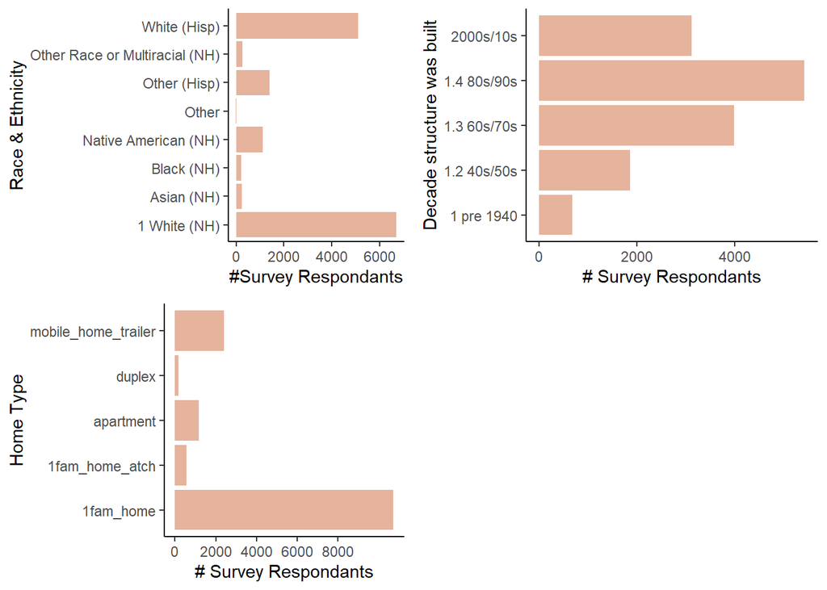

```r
# 4 figures arranged in 2 rows and 2 columns

#Explore Race and Ethnicity Variables

r_e <- ggplot(assignment4_vars, aes(x = race_ethn)) +
  geom_bar(fill="sienna3", alpha=.5) +
   theme(axis.text.x = element_text(angle = 90)) +
   scale_x_discrete(name="Race & Ethnicity") +
    scale_y_continuous(name= "#Survey Respondants",
                       breaks = seq(0,8000, by = 2000),
                     labels = paste(seq(0,8000, by = 2000),
                     "", sep = "")) +
  coord_flip()+
  theme_classic()



#Explore Building Type

bld <- ggplot(assignment4_vars, aes(x =bld_type)) +
  geom_bar(fill="sienna3", alpha =.5) +
   theme(axis.text.x = element_text(angle = 90)) +
   scale_x_discrete(name="Home Type") +
    scale_y_continuous(name= "# Survey Respondants",
                       breaks = seq(0,8000, by = 2000),
                     labels = paste(seq(0,8000, by = 2000),
                     "", sep = "")) +
  coord_flip() +
  theme_classic()




# Explore Decade Home Was Built
dev <- ggplot(assignment4_vars, aes(x = when_built)) +
  geom_bar(fill= "sienna3", alpha=.5) +
   theme(axis.text.x = element_text(angle = 90)) +
  scale_x_discrete(name="Decade structure was built") +
    scale_y_continuous(name= "# Survey Respondants",
                       breaks = seq(0,8000, by = 2000),
                     labels = paste(seq(0,8000, by = 2000),
                     "", sep = "")) +
  coord_flip() +
  theme_classic()

# Plot Together

grid.arrange(r_e,dev, bld, ncol=2, nrow=2)
```

##### Further Explore R&E to condense categories

Based on the previous graphs, I wanted a graph that would show me more clearly the numbers in each category. After unsuccessfully looking for how to at geom_text to the bar graph with only an x variable, I found another way to see this information visually.

```r
table(assignment4_vars$race_ethn)
```

```
##
##                   1 White (NH)                     Asian (NH)
##                           6694                            237
##                     Black (NH)           Native American (NH)
##                            212                           1124
##                          Other                   Other (Hisp)
##                             14                           1399
## Other Race or Multiracial (NH)                   White (Hisp)
##                            272                           5091
```

```r
count(assignment4_vars, 'race_ethn')
```

```
##                        race_ethn freq
## 1                   1 White (NH) 6694
## 2                     Asian (NH)  237
## 3                     Black (NH)  212
## 4           Native American (NH) 1124
## 5                          Other   14
## 6                   Other (Hisp) 1399
## 7 Other Race or Multiracial (NH)  272
## 8                   White (Hisp) 5091
```

```r
r_e_2 <- tab1(assignment4_vars$race_ethn, sort.group ="decreasing", cum.percent =TRUE)
```

[figure not shown]

## **Model**

Below is a model for Household Income (dependent variable) that takes into consideration When the Structure/Home was built, Race&Ethnicity of the respondent, building type, number of individuals in the household, and age of respondent.

The base cases are set to:

*Race/Ethnicity:* White (NH)  
*Home Type:* One family home, detached  
*decade constructed*: Pre-1940s

##### MODEL 1: Baseline

```r
model <- lm(HINCP ~ when_built + race_ethn + bld_type + AGEP + NP, data =assignment4_vars)
summary(model)
```

```
##
## Call:
## lm(formula = HINCP ~ when_built + race_ethn + bld_type + AGEP +
##     NP, data = assignment4_vars)
##
## Residuals:
##     Min      1Q  Median      3Q     Max
## -138696  -41948  -15562   18241  719379
##
## Coefficients:
##                                          Estimate Std. Error t value Pr(>|t|)
## (Intercept)                              62760.97    3838.27  16.351  < 2e-16
## when_built1.2 40s/50s                    -4950.64    3398.86  -1.457   0.1453
## when_built1.3 60s/70s                     2560.48    3160.77   0.810   0.4179
## when_built1.4 80s/90s                    12672.62    3128.61   4.051 5.14e-05
## when_built2000s/10s                      24360.14    3232.57   7.536 5.13e-14
## race_ethnAsian (NH)                      -9361.67    5004.05  -1.871   0.0614
## race_ethnBlack (NH)                     -24271.76    5268.78  -4.607 4.12e-06
## race_ethnNative American (NH)           -50486.23    2483.47 -20.329  < 2e-16
## race_ethnOther                          -11863.03   20202.91  -0.587   0.5571
## race_ethnOther (Hisp)                   -26795.09    2252.24 -11.897  < 2e-16
## race_ethnOther Race or Multiracial (NH)  -7041.73    4688.42  -1.502   0.1331
## race_ethnWhite (Hisp)                   -28909.41    1455.65 -19.860  < 2e-16
## bld_type1fam_home_atch                   -8280.26    3267.12  -2.534   0.0113
## bld_typeapartment                       -39749.21    2379.80 -16.703  < 2e-16
## bld_typeduplex                          -38814.70    5891.96  -6.588 4.61e-11
## bld_typemobile_home_trailer             -37563.17    1791.57 -20.967  < 2e-16
## AGEP                                       185.55      30.69   6.045 1.53e-09
## NP                                        8400.14     429.75  19.547  < 2e-16
##
## (Intercept)                             ***
## when_built1.2 40s/50s
## when_built1.3 60s/70s
## when_built1.4 80s/90s                   ***
## when_built2000s/10s                     ***
## race_ethnAsian (NH)                     .
## race_ethnBlack (NH)                     ***
## race_ethnNative American (NH)           ***
## race_ethnOther
## race_ethnOther (Hisp)                   ***
## race_ethnOther Race or Multiracial (NH)
## race_ethnWhite (Hisp)                   ***
## bld_type1fam_home_atch                  *
## bld_typeapartment                       ***
## bld_typeduplex                          ***
## bld_typemobile_home_trailer             ***
## AGEP                                    ***
## NP                                      ***
## ---
## Signif. codes:  0 '***' 0.001 '**' 0.01 '*' 0.05 '.' 0.1 ' ' 1
##
## Residual standard error: 75380 on 15025 degrees of freedom
## Multiple R-squared:  0.1216, Adjusted R-squared:  0.1206
## F-statistic: 122.3 on 17 and 15025 DF,  p-value: < 2.2e-16
```

### **Analysis:**

In this model, I am looking at how Household Income varies with race/ethnicity, the decade a structure was built, the type of home it is, number of people in the individuals household, and the age of the individual. The population I am looking at is a sample of individuals in New Mexico who have reported non-negative Household Income.

**How does the type of home impact household income?**

Using detached single-family homes as a base case we see that:

If someone was living in an apartment, they would on average have a household income that was $39,750 less. This relationship is statistically significant with a p-value of 2e-16.

**How does when the structure/home was built impact household income?**

Using structures built before 1940 as the base case we see that:

There is not a statistically significant relationship between pre-1940s buildings and buildings built in the 40s/50s or 60s/70s, however, there are statistically significant relationship between pre-1940s buildings and buildings built since the 1980s.

**How does race & ethnicity impact household income?**

For race & ethnicity, I think it is important to evaluate who to use as the base-case. For this analysis I chose to use non-Hispanic whites as the base since they are the largest share of the respondents.

Using non-Hispanic whites as the base case we see that:

These numbers are pretty staggering, but line up with what I understand about poverty in some of the more rural areas of the state, especially on the Navajo Nation Reservation in the northern part of the state. For the next assignment, I think I will want to look at bernallilo county specifically to see if these disparities are as pronounced within abq and surrounding towns as they are across the whole state.

**How does age impact household income?**

In our model we see that Age has an positive relationship with household income. One additional year older corresponds with, on average, a $185.54 increase in household income, it is statistically significant with a p-value of 1.5e-09. One thing that is interesting is that before I added Number of People in household to this regression, the relationship was inverse, for every increase in age there was a ~$100 reduction in income. At the time I thought that this could possibly be explained by New Mexico’s challenges with high rates of poverty among elderly populations. Now, I am a little puzzled thinking about why adding the additional variable would have flipped this relationship.

**How does number of people living in the household impact household income?**

## **R Cheat Sheet, References & Troubleshooting**

Hello! I see this area of my assignment as predominantly a resource for myself as I learn R and as a resource to R if I ever need to return after a hiatus (and have forgotten everything I know).

Feel free to look through, but there is no need to grade anything in this section.

R Collaborative Flowchart: https://miro.com/app/board/o9J_klc5-mA=/

** Sage’s Troubleshooting Checklist**  
0. Breathe.  
1. Is everything spelled/cApiTAlized correctly?  
2. Count your parentheses(), commas, and “quotes”  
2.1 Check poles %>%, |  
3. Have you run the R chunks that are before the chunk with your error.  
5. What is the last thing you changed? Did you make sure you changed it in ALL the places it needs to be changed?  
6. Breathe. Maybe get a glass of water.  
7. Type in the ?function() into the Console  
8. Do a Google search for “R Markdown” + Your Problem  
9. Try retyping the function from scratch. 10. Try copying and pasting sections in another R Chunk –> Isolate the Problem  
11. Phone a friend.

**Common Errors:**  
-If you are having a function not found error, check whether or not you have run your libraries.  
-YAML error, check the very beginning of your code -

**If you want to see the values of a variable as they appear in your dataset** #Race  
#unique(household_data$RAC1P_label) <br/> #Hispanic <br/> #unique(household_data$HISP_label)

### References

**For General R** R is for Data Science https://r4ds.had.co.nz/index.html

Data Wrangling Cheat Sheet https://rstudio.com/wp-content/uploads/2015/02/data-wrangling-cheatsheet.pdf

*formatting* https://rstudio.com/wp-content/uploads/2015/02/rmarkdown-cheatsheet.pdf

*For GGPLOT** Top 50 Graph Types http://r-statistics.co/Top50-Ggplot2-Visualizations-MasterList-R-Code.html#Violin%20Plot

GGplot Cheat Sheet https://rstudio.com/wp-content/uploads/2015/03/ggplot2-cheatsheet.pdf

Color Pallets https://www.datanovia.com/en/blog/ggplot-colors-best-tricks-you-will-love/#predefined-ggplot-color-palettes

Look into Wes Anderson Themes, WSJ, Economist

**Number Crunching**

Another Way of Pulling Summary  
#mean(household_data$HINCP) <br/> #quantile(household_data$HINCP)  
#sd(household_data$HINCP)

Simple Explanation of Dsitributions: https://nezumisa.wordpress.com/2013/06/03/different-types-of-distributions/